# Chapter5: Regression Analysis Using the Proportional Hazards Model

### Covariates and nonparametric survival models

In the previous chapter we saw how to compare two survival distributions without assuming a particular parametric form for the survival distributions, and we also introduced a parameter $\psi$ that indexes the difference between the two survival distributions via the Lehmann alternative, $S_1(t) = [S_0(t)]^{\psi}$.  
We can see that we can re-express this relationship in terms of the hazard functions, yielding the **proportional hazards assumption**,

$$h_1(t) = \psi h_0(t)$$

This equation is the key to quantifying the difference between two hazard functions, and the proportional hazards model is widely used. Furthermore, we can extend the model to include covariate information in a vector z as follows:

$$\psi = e^{z \beta}$$

While other functional relationships between the proportional hazards constant $\psi$ and covariates $z$ are possible, this is by far the most common in practice.

This proportional hazards model will allow us to fit regression models to censored survival data, much as one can do in linear and logistic regression. However, not assuming a particular parametric form for $h_0(t)$, along with the presence of censoring, makes survival modeling particularly complicated.  
In this chapter we shall see how to do this using what we shall call a **partial likelihood**.  
This modification of the standard likelihood was developed initially by D.R. Cox, and hence is often referred to as the **Cox proportional hazards model**.

### Comparing two survival distributions using a partial likelihood function

Parametric distributions require strong assumptions about the form of the underlying survival distribution. However, the partial likelihood will allow us to use an unspecified baseline survival distribution to define the survival distributions of subjects based on their covariates.  
(パラメトリックモデルはベースラインの生存確率に何らかの仮定を置かないといけないが後述のように部分尤度を用いるとベースラインハザードや打ち切りを加味しない)

The partial likelihood differs from a likelihood in two ways.

- it is a product of expressions, one for each failure time, while censoring times do not contribute any factors. (各イベント発生時の確率の積和なので打ち切りやイベント間の時間に関しては考えない。log-rankと同じような考え方)
- the factors of a partial likelihood are conditional probabilities. (全尤度と異なり条件付き確率である)

Let’s fix some notation.  
We will use $j$ to denote the $j$’th failure time (where the failure times are sorted from lowest to highest). The hazard function for Subject $i$ at failure time $t_j$ is $h_i(t_j)$.  
Under the proportional hazards model, we may write this hazard function as $h_1(t_j) = \psi_i h_0(t_j)$, and $\psi_i = e^{z_i \beta}$.

Consider now the first failure time $t_1$. The set of all subjects in the trial “at risk” for failure at this time is denoted by $R_1$. Among the patients in the risk set $R1$, all are at risk of failure (i.e. of experiencing the event), and one of them, say Patient $i$, does fail. (We assume for now that there are no ties.) The probability that Patient $i$ is the one who fails is the hazard,  
$h_i(t_1) = h_0(t_1)\psi$, for that patient divided by the sum of the hazards of all of the patients:

$$p_1 = \frac{h_i(t_1)}{\displaystyle \sum_{k \in R_1} h_k(t_1)}
= \frac{h_0(t_1)\psi_i}{\displaystyle \sum_{k \in R_1} h_0(t_1)\psi_k}$$
where $h_0(t1)$ is the hazard for a subject from the control group. The expression “$k\in R_1$” under the summation sign indicates that the sum is taken over all patients in the risk set $R_1$.
($t_1$で患者$i$がイベントを起こす確率は、$t_1$の時の$i$のハザード/$i$を含めたat risk全体のハザードの和で算出する)

A key fact here is that the baseline hazard $h_0(t_1)$ cancels out of the numerator and denominator, so that we have

$$p_1 = \frac{\psi_i}{\displaystyle \sum_{k \in R_1} \psi_k}$$
After the event at $t_1$, that patient drops out of the risk set $R1$, as do any censored observations that occur after $t1$ up to and including the second failure time $t2$, resulting in a new (and smaller) risk set $R2$. We then repeat this calculation to obtain $p2$, and so on up to the last failure time.
The partial likelihood is the product $L(\psi) = p_1 \cdot p_2 \cdot p_3 \cdots p_D$, assuming that there are $D$ failure times. (同じような操作を全てのイベント発生時で繰り返す。これらの同時確率$L(\psi)$が最大となるような$\psi$が$\psi$の最優推定地となる)
In each factor the baseline hazard cancels out of the numerator and denominator, so that it plays no role in the final partial likelihood. (ベースラインハザード$h_0(t)$がキャンセルされるのでベースラインハザードを推定する必要がない！)

注意) COX比例ハザードモデルの注意点

- 大前提として$h(t) = h_0(t) \cdot e^{z\beta}$という強い仮定(比例ハザード性質+ハザード比が$e$の線型性で表現できる)
- log-rank検定と同様にイベントの発生時間や打ち切りはモデルに組み込まれていない。$t_1=1$, $t_2=100$の様な極端な例の場合はモデルの適応に注意しなければならない。

*Example:*  
Let us consider again the synthetic data in below

```r
(df <- tibble(patient = 1:6,
             survtime = c(6, 7, 10, 15, 19, 25),
             censor = c(1, 0, 1, 1, 0, 1),
             group = c("C", "C", "T", "C", "T", "T")))
```

```
## # A tibble: 6 x 4
##   patient survtime censor group
##     <int>    <dbl>  <dbl> <chr>
## 1       1        6      1 C
## 2       2        7      0 C
## 3       3       10      1 T
## 4       4       15      1 C
## 5       5       19      0 T
## 6       6       25      1 T
```

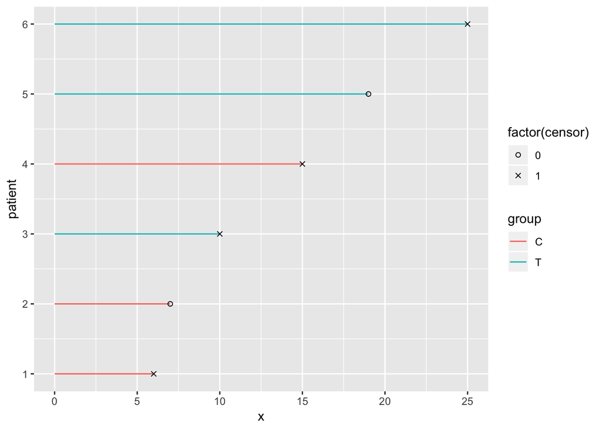

```r
ggplot(df) +
  geom_segment(aes(x = 0, xend = survtime, y = patient, yend = patient, color = group)) +
  geom_point(aes(x = survtime, y = patient, shape = factor(censor))) +
  scale_shape_manual(values = c(1, 4)) +
  scale_y_continuous(breaks = seq(1, 6, by = 1))
```

At time0, there are six patients in the data set, all of which are at risk of experiencing an event. We call this group of patients the initial risk set $R1$. Just before the first failure time, $t = 6$, there are still six patients at risk, any one of which could experience the event. For our simple example, we have $\psi_1 = \psi_2 = \psi_4 = 1$ (control) and $\psi_3 = \psi_5 = \psi_6 = \psi$ (treatment).  
Substituting into above Eq we have, for the event at time 6.

$$p_1 = \frac{1 \cdot h_0(t_1)}{3 \cdot h_0(t) \cdot \psi + 3 \cdot h_0(t)} = \frac{1}{3\psi + 3}$$

That is, there are six patients at risk, with six corresponding terms in the denominator.  
One of them fails, a control patients, so a “1” appears (control) in the numerator.

The factor for the second failure time may be found in the same way.  
Of the six patients at risk at the first time, one dropped out because of a failure, and also a control patient dropped out at time 7 due to censoring. The factor for the second failure time, $t = 10$, is thus

$$p_2 = \frac{\psi}{3\psi + 1}$$

For the third failure time, $t = 15$, there are three patients at risk, one control and two treated. A control patient fails, so we have

$$p_3 = \frac{1}{2\psi + 1}$$
Finally, at the last event $t = 25$, there is only one subject at risk, who has the event, so the last factor is just 1.
The partial likelihood is the product of these expressions,

$$\begin{align}
L(\psi) &= p_1 \cdot p_2 \cdot p_3 \cdot p_4 \\
&= \frac{1}{3\psi + 3} \cdot \frac{\psi}{3\psi + 1} \cdot \frac{1}{2\psi + 1} \cdot 1 \\
&= \frac{\psi}{(3\psi + 3)(3\psi + 1)(2\psi + 1)}
\end{align}$$
Working with this function will be easier if we make the variable transformation $\psi = e^{\beta}$.
Then we have

$$\begin{align}
l(\beta) &= \log(\psi) - \log(3\psi + 3) - \log(3\psi + 1) - \log(2\psi + 1) \\
&= \beta - \log(3e^{\beta} + 3) - \log(3e^{\beta} + 1) - \log(2e^{\beta} + 1)
\end{align}$$
The maximum partial likelihood estimate is the value of $\psi$ that maximizes this function which, as we have said, is independent of the baseline hazard function $h_0(t)$.
Notice that the particular values of the failure times do not contribute to this function; only the order matters.

Also notice that, unlike a likelihood function, this partial likelihood is not a probability, since factors for censored times are not included.  
Still, one can treat this as if it were a likelihood, and find the maximum partial likelihood estimate of $\beta$ In R, we may do this by first defining the function $l(\beta)$:

```r
# define l(beta)
likely_beta <- function(beta) {
  beta - log(3 * exp(beta) + 3) - log(3 * exp(beta) + 1) - log(2 * exp(beta) + 1)
}

# detect m.p.l.e. (maximum partial likelihood estimate) using the “optim” function.
(m_p_l_e = optim(par = 0, fn = likely_beta, method = "L-BFGS-B",
                control=list(fnscale = -1),
                lower = -3, upper = 1))
```

```
## $par
## [1] -1.326129
##
## $value
## [1] -3.671981
##
## $counts
## function gradient
##        6        6
##
## $convergence
## [1] 0
##
## $message
## [1] "CONVERGENCE: REL_REDUCTION_OF_F <= FACTR*EPSMCH"
```

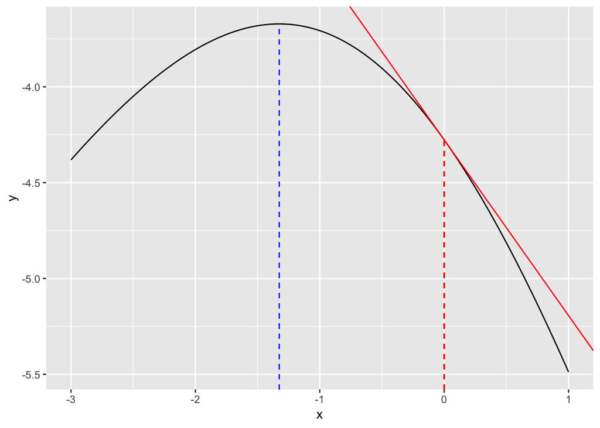

```r
# plot l(beta)
ggplot(data = tibble(x = seq(-3, 1, by = 0.1)), aes(x = x)) +
  stat_function(fun = likely_beta) +
  geom_segment(x = m_p_l_e$par, xend = m_p_l_e$par, y = -Inf, yend = likely_beta(m_p_l_e$par),
               linetype = "dashed", color = "blue") +
  geom_segment(x = 0, xend = 0, y = -Inf, yend = likely_beta(0), linetype = "dashed", color = "red") +
  geom_abline(slope = -0.917, intercept = likely_beta(0), color = "red")
```

The solid curved black line is a plot of the log partial likelihood over a range of values of $\beta$.  
The maximum is indicated by the vertical dashed blue line, and the value of the *l.p.l.* at that point is -3.672.  
Also shown is the value -4.2766661 of the *l.p.l.* at the null hypothesis value, $\beta = 0$.  
The tangent to the $l(\beta)$ curve at $\beta = 0$ is shown by the straight red line.  
Its slope is the derivative of the log-likelihood (i.e. the score function) evaluated at $\beta = 0$.

Interestingly, this is exactly the (absolute value of) the log-rank statistic $U_0$ which we obtained in the previous chapter.  
This simple example illustrates a general principle: *The score function, obtained by taking the derivative of the log partial likelihood, evaluated at* $\beta = 0$*, is equivalent to the log-rank statistic*.

### Partial likelihood hypothesis tests

In standard likelihood theory, one can derive three forms of the test of $H_0:\beta = 0$: **the Wald test**, **the score test**, and **the likelihood ratio test**.  
(部分尤度で推定した$\beta$が統計的に$\beta = 0$ではないつまり係数が統計的に有意かどうかを確認する。)  
In survival analysis, we may use the partial likelihood to derive these three tests, although the underlying statistical theory for the partial likelihood is far more complex than that for standard likelihood theory.  
Often - but not always - the three tests yield similar results.

To develop the tests, we need two functions derived from the partial log likelihood.  
($S(\beta)$や$I(\beta)$の関係性についてはChapter2を参照)  
The first, **the score function**, is the first derivative of the log likelihood, $S(\beta) = l'(\beta)$.  
The second function, **the information**, is minus the derivative of the score function, or equivalently minus the second derivative of the log-likelihood, $I(\beta) = -S'(\beta) = -l''(\beta)$.  
The second derivative $l''(\beta)$ is also known as the **Hessian**.  
With the substitution of the parameter estimate $\hat{\beta}$ into the information, we obtain the **observed information**.

### The Wald test

The Wald test is perhaps the most commonly used test, and carrying it out is straightforward from computer output.  
The test statistic is of the form $Z = \hat{\beta}/s.e.(\hat{\beta})$, where “s.e.” stands for “standard error.”  
($\hat{\beta}/s.e.(\hat{\beta})$が標準正規分布に従うことを利用して検定を行う。)

In the previous section, we saw that $\hat{\beta}$ was the value of $\beta$ hat maximizes $l(\beta)$. We know from basic differential calculus that we may find the maximum by solving $S(\beta) = l'(\beta) = 0$ for $\beta$.  
To find the variance of $\hat{\beta}$, we evaluate the information, $I(\beta) = -l''(\beta)$. The variance of $\hat{\beta}$ is approximately $1/I(\hat{\beta})$, and the standard error is $s.e.(\hat{\beta}) = 1 / \sqrt{I(\hat{\beta})}$.  
We may use this to construct a normalized test statistic $Z_w = \hat{\beta} / s.e.(\hat{\beta})$, and reject $H_0:\beta = 0$ if $|Z_w| > Z_{\alpha / 2}$.  
We can also construct a $1-\alpha$ confidence interval, $\hat{\beta} \pm z_{\alpha / 2} \cdot s.e.(\hat{\beta})$.  
Equivalently, we can use the fact that the square of a standard normal random variable has a chi-square distribution with one degree of freedom, and reject the null hypothesis if $Z_w^2 > \chi^2_{\alpha, 1}$.

### The score test

We evaluate the score and information at the null hypothesis value of $\beta$, normally $\beta = 0$.  
The test statistic is $Z_s = S(\beta = 0)/ \sqrt{I(\beta = 0)}$, and we reject $H_0: \beta = 0$ if $|Z_s| > z_{\alpha / 2}$, or equivalently if $Z_s^2 > \chi^2_{\alpha, 1}$.  
($Z_s$は$S(\beta = 0)/ \sqrt{I(\beta = 0)}$より$\hat{\beta}$がわからなくても統計量を計算できる)  
The score test is equivalent to the log-rank test, as we saw in the previous section. This test can be carried out without finding the maximum likelihood estimate $\hat{\beta}$.

### The likelihood ratio test

The likelihood ratio test uses the result from statistical theory that $2[l(\beta = \hat{\beta}) - l(\beta = 0)]$ follows approximately a chi-square distribution with one degree of freedom.  
The key advantage of this test over the other two is that it is invariant to monotonic transformations of $\beta$. (前の二つと違って単調増加関数に対しても使える)  
For example, whether the test is computed in terms of $\beta$ or in terms of $\psi = e^{\beta}$ has no effect at all on the p-value for testing $H_0:\beta = 0$.

ちなみに各検定がa-hat≠a_0を検定するのに評価するのは下図の様なイメージ

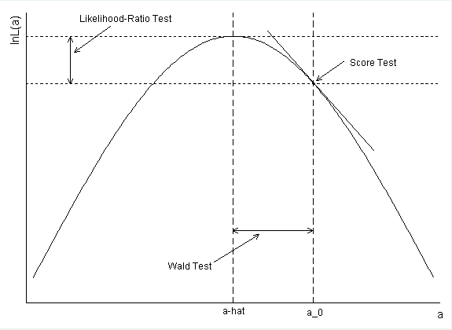

*Example:* We begin by presenting the output from the `coxph` function.  
The result is put into a data structure called “result_cox”, and a complete summary of the results we obtain using the `summary` function,

```r
# Using propotional hazard function
result_cox <- coxph(Surv(survtime, censor) ~ group, data = df)

# Show summary of result_cox
summary(result_cox)
```

```
## Call:
## coxph(formula = Surv(survtime, censor) ~ group, data = df)
##
##   n= 6, number of events= 4
##
##           coef exp(coef) se(coef)     z Pr(>|z|)
## groupT -1.3261    0.2655   1.2509 -1.06    0.289
##
##        exp(coef) exp(-coef) lower .95 upper .95
## groupT    0.2655      3.766   0.02287     3.082
##
## Concordance= 0.7  (se = 0.116 )
## Likelihood ratio test= 1.21  on 1 df,   p=0.3
## Wald test            = 1.12  on 1 df,   p=0.3
## Score (logrank) test = 1.27  on 1 df,   p=0.3
```

We will explain the computations of the estimates and test statistics as follows. We use the associated log partial likelihood function ‘likely_beta’.  
We may compute the derivative of the log-likelihood (i.e. the score) evaluated at $\beta = 0$ numerically using the `gradient` function in the package `numDeriv` (which must be separately downloaded and installed),

```r
library(numDeriv)

# Caluculate l'(beta = 0) = S(beta = 0)
grad(likely_beta, x = 0)
```

```
## [1] -0.9166667
```

The result -0.917 is thus the score evaluated at the null hypothesis, and is the slope of the red tangent line in above Fig. To carry out the score test, we also need the information, which we obtain using the `hessian` function as follows:

```r
# Caluculate -l''(beta = 0) = I(beta = 0)
hessian(likely_beta, x = 0)
```

```
##            [,1]
## [1,] -0.6597171
```

This is the curvature of the log-likelihood at the point where the tangent touches the log-likelihood in Fig.  
The score test statistic, expressed as $Z_s^2$, is the square of the score at $\beta = 0$ divided by minus the hessian (information), also at $\beta = 0$, as follows:

```r
(score_log_rank <- grad(likely_beta, x = 0) ^ 2 / abs(hessian(likely_beta, 0)))
```

```
##          [,1]
## [1,] 1.273694
```

This is the result given on **“Score (logrank) test”** of the summary output. The score test p-value is given by the upper tail,

```r
pchisq(score_log_rank, df = 1, lower.tail = FALSE)
```

```
##           [,1]
## [1,] 0.2590748
```

This score test p-value is also given on **“Score (logrank) test”**.

We compute the **Wald test**.  
The parameter estimate and standard error are given on “groupT coef”. Finally, the Wald test statistic $Z_w$ and two-sided p-value for the test are given by

```r
# calculate Z_w = beta-hat / s.e(beta_hat)
(wald_log_rank <- m_p_l_e$par / sqrt(1 / -hessian(likely_beta, x = m_p_l_e$par)))
```

```
##           [,1]
## [1,] -1.060171
```

```r
# p.value of 2-sided
pnorm(abs(wald_log_rank), lower.tail = F) * 2
```

```
##           [,1]
## [1,] 0.2890667
```

The likelihood ratio statistic is twice the difference in the log partial likelihoods evaluated at $\hat{\beta}$ and at 0;

```r
# calculate likelihood estimation
(likelihood_log_rank <- 2 * (likely_beta(m_p_l_e$par) - likely_beta(0)))
```

```
## [1] 1.209369
```

```r
# p.value
pchisq(likelihood_log_rank, df = 1, lower.tail = FALSE)
```

```
## [1] 0.2714571
```

$$R^2 = 1 - \left(\frac{l(0)}{l(\beta)}\right)^{2/n}$$

and reflects the improvement in the fit of the model with the covariate compared to the null model.

The “Concordance” is the C-statistic, a measure of the predictive discrimination of a covariate. See Harrell for more details.

### The Partial Likelihood with Multiple Covariates

We now develop in greater generality the partial likelihood.  
We define the hazard ratio (relative to the baseline hazard) for subject $i$ by $\psi_i = e^{z'_i\beta}$. As in the previous section, $z_i$ is a vector of covariate values for subject $i$, and $\beta$ is a vector of coefficients, with one coefficient for each covariate. The hazard ratio parameter could be written more completely as $\psi(z_i, \beta)$, but for we will generally use $\psi_i$ for brevity.  
Just before the first failure time, all of the subjects are said to be “at risk” for failure, and among these, one will fail. The “risk set” is the set of all individuals at risk for failure, and is denoted by $R_j$. The partial likelihood is a product of terms, one for each failure time. For each factor, (i.e., for each $j$), the denominator is the sum of all risks in the risk set $R_i$ (denoted by “$k \in R_j$”) of $h_k = h_o\psi_k$ and the numerator is the hazard $h_j = h_0 \psi_j$ for the individual in the risk set $R_j$ who experienced the failure.  
As we saw previously, the baseline hazards $h_0(t_j)$ cancel out of all of the terms, as follows:

$$L(\beta) = \prod_{j = 1}^{D}\frac{h_0(t_j)\psi_j}{\displaystyle \sum_{k \in R_j}h_0(t_j)\psi_k} = \prod_{j = 1}^{D} \frac{\psi_j}{\displaystyle \sum_{k \in R_j}\psi_k}$$
where the product is taken over all of the deaths. This function is called a partial likelihood because it lacks factors for the censored observations. Nevertheless, it may be used as if it were a likelihood, an idea first proposed by Cox.

The log partial likelihood is as follows, using D to represent the number of deaths in the set $D$:

$$l(\beta) = \displaystyle \sum_{j = 1}^{D}\left[\log{\psi_j} - \log{(\displaystyle \sum_{k \in R_j}\psi_k)}\right]
= \displaystyle \sum_{j = 1}^{D}z'_j \beta - \displaystyle \sum_{i = 1}^{D} \log{(\displaystyle
\sum_{k \in R_j} e^{z'k \beta}})$$

The score function, which is the first derivative of $l(\beta)$, has $p$ components, one for each of the $p$ covariates.  
The $l$’th component is given by (recalling that $\log{(\psi_j)} = z'_j\beta$, and using the fact that $z_{jl} = \partial \log{\psi_j}/ \partial \beta_l$)

$$S_l(\beta) = \frac{\partial l \beta}{\partial \beta_l} =
\displaystyle \sum_{j = 1}^{D} \left(z_{jl} - \frac{\displaystyle \sum_{k \in R_j} z_{jk} e^{z'_j\beta}}
{\displaystyle \sum_{k \in R_j} e^{z'_j\beta}}\right)$$

As we will see in Chap. 7, we may view the score function as the sum of **residuals**, each of which consists of the observed value $z_{ij}$ of the covariate minus an **expected** value.  
In the special case where $z_i$ is a single binary covariate, $S(\beta = 0)$ is the log-rank statistic.  
To construct test statistics as we did, we will need the second derivative of the log-likelihood with respect to all pairwise combinations of the $k$ covariates.  
Writing the score function as a vector with $k$ components, we may define the *observed information* matrix as follows:

$$I(\beta ; z) = -\frac{\partial^2 l(\beta)}{\partial\beta\partial\beta'}
= - \frac{\partial S(\beta)}{\partial \beta}$$

Also known as the *Hessian* matrix, this may be derived using standard differential calculus.  
The Wald, score, and likelihood ratio test statistics of $H_0: \beta = 0$ are, respectively,

$$X_w^2 = \hat{\beta}' I(\hat{\beta};z)\hat{\beta} \\
X_s^2 = S'(\beta = 0;z)\cdot I^{-1}(\beta = 0;z)\cdot S(\beta = 0;z) \\
X_l^2 = 2 \{l(\beta = \hat{\beta}) - l(\beta = 0)\}$$

### Estimating the Baseline Survival Function

An estimate of the baseline hazard function is given by

$$h_0(t_i) = \frac{d_i}{\displaystyle \sum_{j \in R_i}\exp{(z_j\hat{\beta})}}$$

($n_i$の代わりにリスク集合の全ハザード総和でハザードを算出。)  
In the case of a single sample, with $\beta = 0$, this reduces to the Nelson-Altschuler-Aalen estimator. ($\beta=0$なら分母は$n_i$と同じになりNAA推定によるハザード推定と同じ)

The baseline survival function is

$$S_0(t) = \exp{[-H_0(t)]}$$

and an estimate may be obtained by estimating $H_0(t)$ as a cumulative sum of the estimated hazards $h_0(t_j)$ for $t_j \le t$. This is the estimator of the survival function of an individual with all covariate values set to zero. For many cases this is not a desirable or even sensible estimate. For example, if one of the covariates is “age of onset”, setting that to zero will not result in a baseline survival curve with any practical meaning.  
($S_0(t)$はあらゆるパラメーターが0の時の生存曲線だが、ageが0の時がベースラインかと言われるとそうじゃないことが多い)

To find a survival curve for a particular covariate value $z$ use

$$S(t|z) = [S_0(t)]^{\exp(z\hat{\beta})}$$

($z$に特定のパラメーターを代入することでパラメーター$z$をもつ患者の生存確率を推定できる)

In R the `basehaz` function will compute a cumulative baseline hazard function. Be sure to use the option “centered = F” to cause it to estimate the cumulative hazard at $\beta = 0$. The default is to estimate it at the mean of the covariates. This will often not make sense, particularly for categorical covariates such as treatment indicator, sex, or race.

```r
# making cox-regression model from pharmacoSmoking
cox_smoking <- coxph(Surv(ttr, relapse) ~ age + gender + race + employment, data = pharmacoSmoking)

summary(cox_smoking)
```

```
## Call:
## coxph(formula = Surv(ttr, relapse) ~ age + gender + race + employment,
##     data = pharmacoSmoking)
##
##   n= 125, number of events= 89
##
##                     coef exp(coef) se(coef)      z Pr(>|z|)
## age             -0.03733   0.96335  0.01085 -3.439 0.000583 ***
## genderMale      -0.01013   0.98992  0.24070 -0.042 0.966417
## racehispanic    -0.58854   0.55514  0.49725 -1.184 0.236577
## raceother       -1.11858   0.32674  1.02345 -1.093 0.274415
## racewhite       -0.27759   0.75760  0.23393 -1.187 0.235367
## employmentother  0.73717   2.09002  0.27570  2.674 0.007499 **
## employmentpt     0.63862   1.89387  0.34098  1.873 0.061083 .
## ---
## Signif. codes:  0 '***' 0.001 '**' 0.01 '*' 0.05 '.' 0.1 ' ' 1
##
##                 exp(coef) exp(-coef) lower .95 upper .95
## age                0.9634     1.0380   0.94308    0.9841
## genderMale         0.9899     1.0102   0.61761    1.5867
## racehispanic       0.5551     1.8014   0.20948    1.4712
## raceother          0.3267     3.0605   0.04396    2.4287
## racewhite          0.7576     1.3199   0.47898    1.1983
## employmentother    2.0900     0.4785   1.21752    3.5878
## employmentpt       1.8939     0.5280   0.97075    3.6948
##
## Concordance= 0.629  (se = 0.03 )
## Likelihood ratio test= 17.32  on 7 df,   p=0.02
## Wald test            = 17.09  on 7 df,   p=0.02
## Score (logrank) test = 17.61  on 7 df,   p=0.01
```

```r
# regerence: age = Female, race = black, employment = ft)

# caluculating base-line hazard of cox_smoking(age = 0, gender = female, race = black, employment = ft)
# caluculating survival of patient (age = 0, gender = male, race = black, employment = ft)
basehaz(cox_smoking, centered = FALSE) %>%
  mutate(not_relapse_female = exp(-hazard),
         not_relapse_male   = not_relapse_female ^ (exp(cox_smoking$coeff["genderMale"]))) %>%
  as_data_frame() %>%
  head()
```

```
## # A tibble: 6 x 4
##   hazard  time not_relapse_female not_relapse_male
##    <dbl> <dbl>              <dbl>            <dbl>
## 1  0.521     0              0.594            0.597
## 2  0.762     1              0.467            0.471
## 3  1.07      2              0.343            0.346
## 4  1.12      3              0.325            0.328
## 5  1.29      4              0.276            0.279
## 6  1.40      5              0.247            0.250
```